# Is gesture-speech physics at work in rhythmic pointing? Evidence from Polish counting-out rhymes

Šárka Kadavá, Aleksandra Ćwiek, Katarzyna Stoltmann, Susanne Fuchs, Wim Pouw

2023-01-06

Load packages:

```r
library(tidyverse) # data wrangling
library(broom) # for tidy model outputs
library(brms)
library(cmdstanr)

# option for Bayesian regression models:
# use all available cores for parallel computing
options(mc.cores = parallel::detectCores())
library(HDInterval) # package for credible interval computation
library(tidybayes) # plotting
library(bayesplot)

# Bayes factor
library(BayesFactor)
library(bayestestR)

# Diagnostics GUI
library(shinystan)
```

## Load data

```r
#current folder (first go to session -> set working directory -> to source file location)
parentfolder <- dirname(getwd())
datasets      <- paste0(parentfolder, '/8_datasets_for_statistical_analysis/') # folder with datasets for statistics
plots         <- paste0(parentfolder, '/10_plots/') # folder for saving plots

# based on explorative analysis, we are exploring acceleration, deceleration in relation with amplitude envelope and F0
# load the datasets
f0_dec <- read.csv(paste0(datasets, "/dataset_f0_dec.csv"))
f0_acc <- read.csv(paste0(datasets, "/dataset_f0_acc.csv"))
env_dec <- read.csv(paste0(datasets, "/dataset_env_dec.csv"))
env_acc <- read.csv(paste0(datasets, "/dataset_env_acc.csv"))

# this is meta information
META <- readxl::read_excel(paste0(parentfolder, "/1_primary_data_to_be_processed/info.xlsx"))
```

Append other meta data, like age, sex, first hand etc.

```r
f0_dec$age <- NA
f0_dec$sex <- NA
f0_dec$first_hand <- NA

f0_acc$age <- NA
f0_acc$sex <- NA
f0_acc$first_hand <- NA

env_dec$age <- NA
env_dec$sex <- NA
env_dec$first_hand <- NA

env_acc$age <- NA
env_acc$sex <- NA
env_acc$first_hand <- NA

# loop over the rows of the df data frame
for (i in 1:nrow(f0_dec)) {
  # get the participant and rhyme values for the current row
  speaker <- as.character(f0_dec[i, "speaker"])

  # find the rows in the info data frame that correspond to the participant value
  rows <- which(META$VP == speaker)

  # loop over the matching rows of the info data frame
  for (j in 1:length(rows)) {
    # get the current row number
    row <- rows[j]
      # add the values for the age, sex, dominant hand, and first hand columns to the df data frame
    f0_dec[i, "age"] <- META[row, "age"]
    f0_dec[i, "sex"] <- META[row, "sex"]
    f0_dec[i, "first_hand"] <- META[row, "first_hand"]
  }
}

# loop over the rows of the df data frame
for (i in 1:nrow(f0_acc)) {
  # get the participant and rhyme values for the current row
  speaker <- as.character(f0_acc[i, "speaker"])

  # find the rows in the info data frame that correspond to the participant value
  rows <- which(META$VP == speaker)

  # loop over the matching rows of the info data frame
  for (j in 1:length(rows)) {
    # get the current row number
    row <- rows[j]
      # add the values for the age, sex, dominant hand, and first hand columns to the df data frame
    f0_acc[i, "age"] <- META[row, "age"]
    f0_acc[i, "sex"] <- META[row, "sex"]
    f0_acc[i, "first_hand"] <- META[row, "first_hand"]
  }
}

# loop over the rows of the df data frame
for (i in 1:nrow(env_dec)) {
  # get the participant and rhyme values for the current row
  speaker <- as.character(env_dec[i, "speaker"])

  # find the rows in the info data frame that correspond to the participant value
  rows <- which(META$VP == speaker)

  # loop over the matching rows of the info data frame
  for (j in 1:length(rows)) {
    # get the current row number
    row <- rows[j]
      # add the values for the age, sex, dominant hand, and first hand columns to the df data frame
    env_dec[i, "age"] <- META[row, "age"]
    env_dec[i, "sex"] <- META[row, "sex"]
    env_dec[i, "first_hand"] <- META[row, "first_hand"]
  }
}

# loop over the rows of the df data frame
for (i in 1:nrow(env_acc)) {
  # get the participant and rhyme values for the current row
  speaker <- as.character(env_acc[i, "speaker"])

  # find the rows in the info data frame that correspond to the participant value
  rows <- which(META$VP == speaker)

  # loop over the matching rows of the info data frame
  for (j in 1:length(rows)) {
    # get the current row number
    row <- rows[j]
      # add the values for the age, sex, dominant hand, and first hand columns to the df data frame
    env_acc[i, "age"] <- META[row, "age"]
    env_acc[i, "sex"] <- META[row, "sex"]
    env_acc[i, "first_hand"] <- META[row, "first_hand"]
  }
}

## make them as factors
f0_dec$age <- as.numeric(f0_dec$age)
f0_dec$sex <- as.factor(f0_dec$sex)
f0_dec$first_hand <- as.factor(f0_dec$first_hand)

f0_acc$age <- as.numeric(f0_acc$age)
f0_acc$sex <- as.factor(f0_acc$sex)
f0_acc$first_hand <- as.factor(f0_acc$first_hand)

env_dec$age <- as.numeric(env_dec$age)
env_dec$sex <- as.factor(env_dec$sex)
env_dec$first_hand <- as.factor(env_dec$first_hand)

env_acc$age <- as.numeric(env_acc$age)
env_acc$sex <- as.factor(env_acc$sex)
env_acc$first_hand <- as.factor(env_acc$first_hand)
```

Contrast coding of binary variables.

```r
f0_dec <- f0_dec %>%
  mutate_at(vars(speaker, point_hand, sp_rate, rhyme, env_syllable, point_direct), as.factor) # convert as factor

#contrast coding
f0_dec <- f0_dec %>%
  mutate(point_hand_s = case_when(point_hand == "_L" ~ 0.5,
                                  point_hand == "_R" ~ -0.5)) %>%
  mutate(sp_rate_s = case_when(sp_rate == "fast" ~ 0.5,
                               sp_rate == "normal" ~ -0.5)) %>%
  mutate(point_direct_s = case_when(point_direct == "backward_movement" ~ 0.5,
                                    point_direct == "forward_movement" ~ -0.5)) %>%
  mutate(sex_s = case_when(sex == "female" ~ 0.5,
                           sex == "male" ~ -0.5)) %>%
  mutate(first_hand_s = case_when(first_hand == "left" ~ 0.5,
                                  first_hand == "right" ~ -0.5))

f0_acc <- f0_acc %>%
  mutate_at(vars(speaker, point_hand, sp_rate, rhyme, env_syllable, point_direct), as.factor) # convert as factor

#contrast coding
f0_acc <- f0_acc %>%
  mutate(point_hand_s = case_when(point_hand == "_L" ~ 0.5,
                                  point_hand == "_R" ~ -0.5)) %>%
  mutate(sp_rate_s = case_when(sp_rate == "fast" ~ 0.5,
                               sp_rate == "normal" ~ -0.5)) %>%
  mutate(point_direct_s = case_when(point_direct == "backward_movement" ~ 0.5,
                                    point_direct == "forward_movement" ~ -0.5)) %>%
  mutate(sex_s = case_when(sex == "female" ~ 0.5,
                           sex == "male" ~ -0.5)) %>%
  mutate(first_hand_s = case_when(first_hand == "left" ~ 0.5,
                                  first_hand == "right" ~ -0.5))


env_dec <- env_dec %>%
  mutate_at(vars(speaker, point_hand, sp_rate, rhyme, env_syllable, point_direct), as.factor) # convert as factor

#contrast coding
env_dec <- env_dec %>%
  mutate(point_hand_s = case_when(point_hand == "_L" ~ 0.5,
                                  point_hand == "_R" ~ -0.5)) %>%
  mutate(sp_rate_s = case_when(sp_rate == "fast" ~ 0.5,
                               sp_rate == "normal" ~ -0.5)) %>%
  mutate(point_direct_s = case_when(point_direct == "backward_movement" ~ 0.5,
                                    point_direct == "forward_movement" ~ -0.5)) %>%
  mutate(sex_s = case_when(sex == "female" ~ 0.5,
                           sex == "male" ~ -0.5)) %>%
  mutate(first_hand_s = case_when(first_hand == "left" ~ 0.5,
                                  first_hand == "right" ~ -0.5))

env_acc <- env_acc %>%
  mutate_at(vars(speaker, point_hand, sp_rate, rhyme, env_syllable, point_direct), as.factor) # convert as factor

#contrast coding
env_acc <- env_acc %>%
  mutate(point_hand_s = case_when(point_hand == "_L" ~ 0.5,
                                  point_hand == "_R" ~ -0.5)) %>%
  mutate(sp_rate_s = case_when(sp_rate == "fast" ~ 0.5,
                               sp_rate == "normal" ~ -0.5)) %>%
  mutate(point_direct_s = case_when(point_direct == "backward_movement" ~ 0.5,
                                    point_direct == "forward_movement" ~ -0.5)) %>%
  mutate(sex_s = case_when(sex == "female" ~ 0.5,
                           sex == "male" ~ -0.5)) %>%
  mutate(first_hand_s = case_when(first_hand == "left" ~ 0.5,
                                  first_hand == "right" ~ -0.5))


# rename because sp_ is forbidden
f0_acc <- rename(f0_acc, speech_rate_s = sp_rate_s)
f0_dec <- rename(f0_dec, speech_rate_s = sp_rate_s)
env_acc <- rename(env_acc, speech_rate_s = sp_rate_s)
env_dec <- rename(env_dec, speech_rate_s = sp_rate_s)
```

For acceleration/deceleration, we need to multiply the data in order to get informative units. We multiply by a 100 to go from meters to centimeters. We multiply by 200 to compensate for the sampling rate (200Hz), so that we yield cm/s^2 Through this modification, we get information in cm/s^2.

```r
f0_acc$wrist_apeak <- f0_acc$wrist_apeak*100*200
f0_dec$wrist_decpeak <- f0_dec$wrist_decpeak*100*200
env_acc$wrist_apeak <- env_acc$wrist_apeak*100*200
env_dec$wrist_decpeak <- env_dec$wrist_decpeak*100*200
```

We also normalize amplitude envelope peak in respective datasets

```r
env_dec$wrist_envpeak_dec_norm <- NA
env_dec$wrist_envpeak_dec_norm <- ave(env_dec$wrist_envpeak_dec, env_dec$speaker, FUN = function(x) scale(x, center = FALSE, scale = TRUE))

env_acc$wrist_envpeak_acc_norm <- NA
env_acc$wrist_envpeak_acc_norm <- ave(env_acc$wrist_envpeak_acc, env_acc$speaker, FUN = function(x) scale(x, center = FALSE, scale = TRUE))
```

Remove the outliers according to Tukey’s 1.5 IQR rule. This code should be run in the console, because the function prompts the user to answer whether they wish to remove the outliers or not.

```r
# Function
#source("http://goo.gl/UUyEzD")
outlierKD <- function(dt, var) {
     var_name <- eval(substitute(var),eval(dt))
     na1 <- sum(is.na(var_name))
     m1 <- mean(var_name, na.rm = T)
     par(mfrow=c(2, 2), oma=c(0,0,3,0))
     boxplot(var_name, main="With outliers")
     hist(var_name, main="With outliers", xlab=NA, ylab=NA)
     outlier <- boxplot.stats(var_name)$out
     mo <- mean(outlier)
     var_name <- ifelse(var_name %in% outlier, NA, var_name)
     boxplot(var_name, main="Without outliers")
     hist(var_name, main="Without outliers", xlab=NA, ylab=NA)
     title("Outlier Check", outer=TRUE)
     na2 <- sum(is.na(var_name))
     cat("Outliers identified:", na2 - na1, "n")
     cat("Propotion (%) of outliers:", round((na2 - na1) / sum(!is.na(var_name))*100, 1), "n")
     cat("Mean of the outliers:", round(mo, 2), "n")
     m2 <- mean(var_name, na.rm = T)
     cat("Mean without removing outliers:", round(m1, 2), "n")
     cat("Mean if we remove outliers:", round(m2, 2), "n")
     response <- readline(prompt="Do you want to remove outliers and to replace with NA? [yes/no]: ")
     if(response == "y" | response == "yes"){
          dt[as.character(substitute(var))] <- invisible(var_name)
          assign(as.character(as.list(match.call())$dt), dt, envir = .GlobalEnv)
          cat("Outliers successfully removed", "n")
          return(invisible(dt))
     } else{
          cat("Nothing changed", "n")
          return(invisible(var_name))
     }
}

# # F0 deceleration

outlierKD(f0_dec, wrist_f0peak_dec)
# Outliers identified: 10 from 3694 observations
# Proportion (%) of outliers: 0.270709258256632
# Mean of the outliers: 382.472775268555
# Mean without removing outliers: 209.680863960029
# Mean if we remove outliers: 209.211830541711
# N after removing outliers: 3684

outlierKD(f0_dec, wrist_decpeak)
# Outliers identified: 187 from 3694 observations
# Proportion (%) of outliers: 5.06226312939903
# Mean of the outliers: -77.9264848218839
# Mean without removing outliers: -10.3832520588668
# Mean if we remove outliers: -6.78171669340226
# N after removing outliers: 3507

# # F0 acceleration

outlierKD(f0_acc, wrist_f0peak_acc)
# Outliers identified: 33 from 3716 observations
# Proportion (%) of outliers: 0.88805166846071
# Mean of the outliers: 396.42739313299
# Mean without removing outliers: 214.004514261006
# Mean if we remove outliers: 212.369989416375
# N after removing outliers: 3683

outlierKD(f0_acc, wrist_apeak)
# Outliers identified: 180 from 3716 observations
# Proportion (%) of outliers: 4.84391819160388
# Mean of the outliers: 76.718684977427
# Mean without removing outliers: 8.66321491124835
# Mean if we remove outliers: 5.19885274724605
# N after removing outliers: 3536

# # Envelope deceleration

outlierKD(env_dec, wrist_envpeak_dec_norm)
# Outliers identified: 37 from 2253 observations
# Proportion (%) of outliers: 1.64225477141589
# Mean of the outliers: 2.22492303838683
# Mean without removing outliers: 0.873184304622414
# Mean if we remove outliers: 0.850614659699452
# N after removing outliers: 2216

outlierKD(env_dec, wrist_decpeak)
# Outliers identified: 86 from 2020 observations
# Proportion (%) of outliers: 4.25742574257426
# Mean of the outliers: -86.7815979181497
# Mean without removing outliers: -10.3434897391038
# Mean if we remove outliers: -6.94448389453405
# N after removing outliers: 1934

# # Envelope acceleration

outlierKD(env_acc, wrist_envpeak_acc_norm)
# Outliers identified: 65 from 2746 observations
# Proportion (%) of outliers: 2.36707938820102
# Mean of the outliers: 2.20559678891246
# Mean without removing outliers: 0.89988656628024
# Mean if we remove outliers: 0.868230033467449
# N after removing outliers: 2681

outlierKD(env_acc, wrist_apeak)
# Outliers identified: 102 from 2523 observations
# Proportion (%) of outliers: 4.04280618311534
# Mean of the outliers: 68.2989020078606
# Mean without removing outliers: 7.95965422385902
# Mean if we remove outliers: 5.41748021561112
# N after removing outliers: 2421
```

# Modeling

## F0 Acceleration

### Preparation

Check for normality of the outcome variable: F0 peak nearest to acceleration peak.

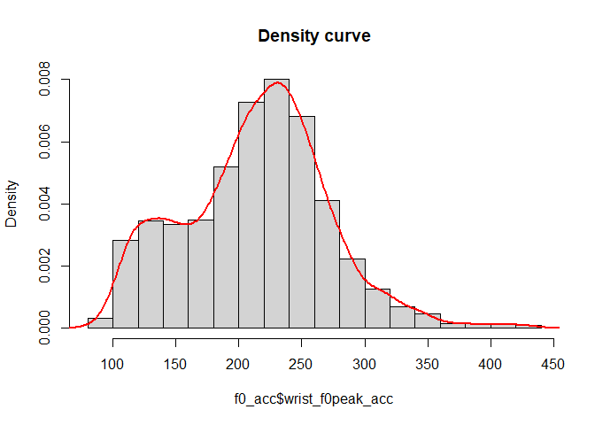

```r
# This distribution, especially the red line will be the one we will later see in the posterior predictive checks as y
hist(f0_acc$wrist_f0peak_acc, freq = FALSE, main = "Density curve")
lines(density(na.omit(f0_acc$wrist_f0peak_acc)), lwd = 2, col = 'red')
```

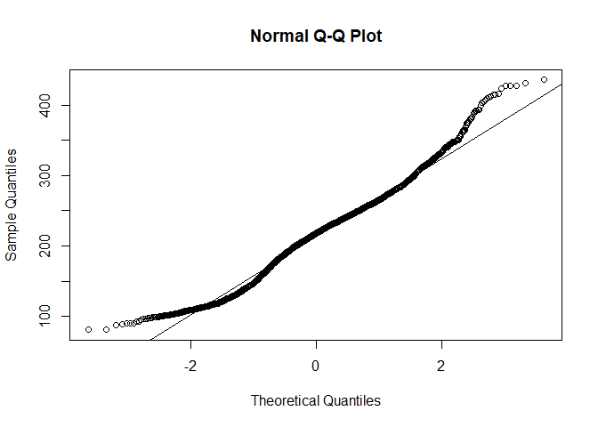

```r
qqnorm(f0_acc$wrist_f0peak_acc)
qqline(f0_acc$wrist_f0peak_acc)
```

```r
shapiro.test(f0_acc$wrist_f0peak_acc)
```

```
##
##  Shapiro-Wilk normality test
##
## data:  f0_acc$wrist_f0peak_acc
## W = 0.98489, p-value < 2.2e-16
```

```r
ks.test(f0_acc$wrist_f0peak_acc, 'pnorm')
```

```
##
##  Asymptotic one-sample Kolmogorov-Smirnov test
##
## data:  f0_acc$wrist_f0peak_acc
## D = 1, p-value < 2.2e-16
## alternative hypothesis: two-sided
```

The outcome variable is not normally distributed.

Now, let’s check for correlation between speech rate and wrist acceleration peak. We use two methods: Bayesian and frequentist.

```r
# Bayes factor
f0acc_corr_s <- correlationBF(f0_acc$speech_rate_s, f0_acc$wrist_apeak)
describe_posterior(f0acc_corr_s)
```

```
## Summary of Posterior Distribution
##
## Parameter | Median |       95% CI |   pd |          ROPE | % in ROPE |       BF |         Prior
## -----------------------------------------------------------------------------------------------
## rho       |   0.09 | [0.06, 0.12] | 100% | [-0.05, 0.05] |        0% | 4.97e+04 | Beta (3 +- 3)
```

```r
bayesfactor(f0acc_corr_s)
```

```
## Bayes Factors for Model Comparison
##
##     Model            BF
## [2] (rho != 0) 4.97e+04
##
## * Against Denominator: [1] (rho = 0)
## *   Bayes Factor Type: JZS (BayesFactor)
```

```r
# Frequentist Kendall
cor(f0_acc$speech_rate_s, f0_acc$wrist_apeak)
```

```
## [1] 0.08864224
```

```r
cor.test(f0_acc$speech_rate_s, f0_acc$wrist_apeak,  method="kendall")
```

```
##
##  Kendall's rank correlation tau
##
## data:  f0_acc$speech_rate_s and f0_acc$wrist_apeak
## z = 27.909, p-value < 2.2e-16
## alternative hypothesis: true tau is not equal to 0
## sample estimates:
##       tau
## 0.3814972
```

Bayes factor points to a very strong evidence for a correlation.

We set weakly informative priors. We truncate the intercept prior to include only positive values, with the lowest point to be 70 Hz. Any lower values would be erroneous octave jumps and they were discarded in the pre-processing.

```r
get_prior(
  wrist_f0peak_acc ~ 1 +
    speech_rate_s +
    point_direct_s +
    wrist_apeak +
    sex_s +
    point_direct_s * wrist_apeak +
    (1 | speaker) +
    (0 + speech_rate_s + point_direct_s + wrist_apeak + point_direct_s * wrist_apeak | speaker) +
    (1 | rhyme) +
    (0 + speech_rate_s + point_direct_s + wrist_apeak + sex_s + point_direct_s * wrist_apeak | rhyme),
  data = f0_acc,
  family = "gaussian"
)

prior1 <- set_prior("truncated_normal(0, 200, lower = 70)", class = "Intercept")
prior2 <- set_prior("normal(0, 75)", class = "b", coef = "sex_s")
prior3 <- set_prior("normal(0, 10)", class = "b", coef = "point_direct_s")
prior4 <- set_prior("normal(0, 1)", class = "b", coef = "point_direct_s:wrist_apeak")
prior5 <- set_prior("normal(0, 10)", class = "b", coef = "speech_rate_s")
prior6 <- set_prior("normal(0, 1)", class = "b", coef = "wrist_apeak")
prior7 <- set_prior("normal(0, 100)", class = "sd")
prior8 <- set_prior("normal(0, 100)", class = "sigma")
prior9 <- set_prior("lkj(2)", class = "cor")
priors_f0_acc <- list(prior1, prior2, prior3, prior4, prior5, prior6, prior7, prior8, prior9)
priors_f0_acc <- prior_summary(priors_f0_acc)
```

### Gaussian + priors

This is the model code.

```r
f0peak_acc <- brm(
  wrist_f0peak_acc ~ 1 +
    speech_rate_s +
    point_direct_s +
    wrist_apeak +
    sex_s +
    point_direct_s * wrist_apeak +
    (1 | speaker) +
    (0 + speech_rate_s + point_direct_s + wrist_apeak + point_direct_s * wrist_apeak || speaker) +
    (1 | rhyme) +
    (0 + speech_rate_s + point_direct_s + wrist_apeak + sex_s + point_direct_s * wrist_apeak || rhyme),
  data = f0_acc,
  family = "gaussian",
  prior = priors_f0_acc,
  # Technical stuff
  backend = "cmdstanr",
  # Number of chains
  chains = 4,
  # Number of iterations per chain
  iter = 10000,
  warmup = 2000,
  # Number of cores to use
  cores = 4,
  # Seed for replicability
  seed = 123,
  # Convergence
  control = list(adapt_delta = 0.99),
  # Save here
  file = paste0(parentfolder, "/9_statistical_analysis_scripts_and_model_output/f0peak_acc_new.rds"))
```

Load ready model:

```r
f0peak_acc = readRDS(paste0(parentfolder, "/9_statistical_analysis_scripts_and_model_output/f0peak_acc_new.rds"))
```

### Output

Look at model output and model fit using posterior predictive checks.

```r
f0peak_acc_pp <- pp_check(f0peak_acc, ndraws = 1000)

# This is the model output
f0peak_acc
```

```
##  Family: gaussian
##   Links: mu = identity
## Formula: wrist_f0peak_acc ~ 1 + speech_rate_s + point_direct_s + wrist_apeak + sex_s + point_direct_s * wrist_apeak + (1 | speaker) + (0 + speech_rate_s + point_direct_s + wrist_apeak + point_direct_s * wrist_apeak || speaker) + (1 | rhyme) + (0 + speech_rate_s + point_direct_s + wrist_apeak + se…
##    Data: f0_acc (Number of observations: 3364)
##   Draws: 4 chains, each with iter = 10000; warmup = 2000; thin = 1;
##          total post-warmup draws = 32000
##
## Multilevel Hyperparameters:
## ~rhyme (Number of levels: 6)
##                                Estimate Est.Error l-95% CI u-95% CI Rhat
## sd(Intercept)                      2.05      1.88     0.08     6.88 1.00
## sd(speech_rate_s)                  1.61      1.64     0.05     5.72 1.00
## sd(point_direct_s)                 7.71      5.15     0.79    20.46 1.00
## sd(wrist_apeak)                    0.58      0.42     0.05     1.60 1.00
## sd(sex_s)                          2.79      2.65     0.09     9.34 1.00
## sd(point_direct_s:wrist_apeak)     0.82      0.74     0.03     2.64 1.00
##                                Bulk_ESS Tail_ESS
## sd(Intercept)                     12552    15592
## sd(speech_rate_s)                 18514    15165
## sd(point_direct_s)                 8529     7508
## sd(wrist_apeak)                    8769     8321
## sd(sex_s)                         12738    14120
## sd(point_direct_s:wrist_apeak)    10862    14835
##
## ~speaker (Number of levels: 11)
##                                Estimate Est.Error l-95% CI u-95% CI Rhat
## sd(Intercept)                     21.89      6.26    13.15    37.24 1.00
## sd(speech_rate_s)                  6.30      2.81     1.28    12.73 1.00
## sd(point_direct_s)                 7.34      3.40     2.47    15.70 1.00
## sd(wrist_apeak)                    0.66      0.47     0.03     1.77 1.00
## sd(point_direct_s:wrist_apeak)     0.54      0.51     0.02     1.90 1.00
##                                Bulk_ESS Tail_ESS
## sd(Intercept)                     10034    16554
## sd(speech_rate_s)                  7230     6743
## sd(point_direct_s)                 7504    10357
## sd(wrist_apeak)                    9772    12474
## sd(point_direct_s:wrist_apeak)     8499    11960
##
## Regression Coefficients:
##                            Estimate Est.Error l-95% CI u-95% CI Rhat Bulk_ESS
## Intercept                    178.56      8.02   162.34   194.55 1.00    10040
## speech_rate_s                  5.22      2.71    -0.19    10.64 1.00    16280
## point_direct_s                -2.16      5.56   -13.05     8.90 1.00    15405
## wrist_apeak                    0.77      0.54    -0.26     1.83 1.00    18407
## sex_s                         97.47     15.65    66.37   129.12 1.00     9294
## point_direct_s:wrist_apeak    -0.32      0.75    -1.80     1.16 1.00    20292
##                            Tail_ESS
## Intercept                     14872
## speech_rate_s                 18761
## point_direct_s                16468
## wrist_apeak                   18679
## sex_s                         14254
## point_direct_s:wrist_apeak    17764
##
## Further Distributional Parameters:
##       Estimate Est.Error l-95% CI u-95% CI Rhat Bulk_ESS Tail_ESS
## sigma    33.02      0.41    32.23    33.82 1.00    48629    24252
##
## Draws were sampled using sample(hmc). For each parameter, Bulk_ESS
## and Tail_ESS are effective sample size measures, and Rhat is the potential
## scale reduction factor on split chains (at convergence, Rhat = 1).
```

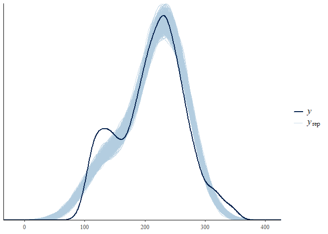

```r
# These are the posterior predictive checks with 1000 samples.
f0peak_acc_pp
```

```r
#ggsave(file.path(plots, "f0peak_acc_pp.pdf"), plot = f0peak_acc_pp, width = 7, height = 4)
```

The fit is not ideal, since it includes an additional “bump.” **Please see supplementary info for more information.**

Now we run some diagnostics.

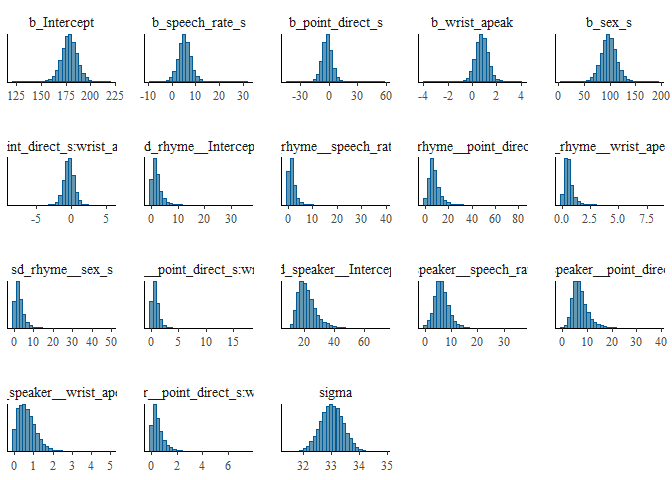

```r
mcmc_plot(f0peak_acc, type="hist")
```

```r
# Please uncomment and run this if you want to see the shinystan GUI and explore the model.
# shiny_f0peak_acc <- launch_shinystan(f0peak_acc)
```

Compute posterior probability of all predictors.

```r
posteriors_f0acc <- posterior_samples(f0peak_acc)
sum(posteriors_f0acc$b_speech_rate_s > 0) / nrow(posteriors_f0acc) # 0.9907187
```

```
## [1] 0.97175
```

```r
sum(posteriors_f0acc$b_point_direct_s < 0) / nrow(posteriors_f0acc) # 0.9185
```

```
## [1] 0.6730625
```

```r
sum(posteriors_f0acc$b_wrist_apeak < 0) / nrow(posteriors_f0acc) # 0.8389062
```

```
## [1] 0.066625
```

```r
sum(posteriors_f0acc$b_sex_s > 0) / nrow(posteriors_f0acc) # 1
```

```
## [1] 1
```

```r
sum(posteriors_f0acc[,6] > 0) / nrow(posteriors_f0acc) # interaction 0.7950312
```

```
## [1] 0.3160625
```

## F0 Deceleration

### Preparation

Check for normality of the outcome variable: F0 peak nearest to deceleration peak.

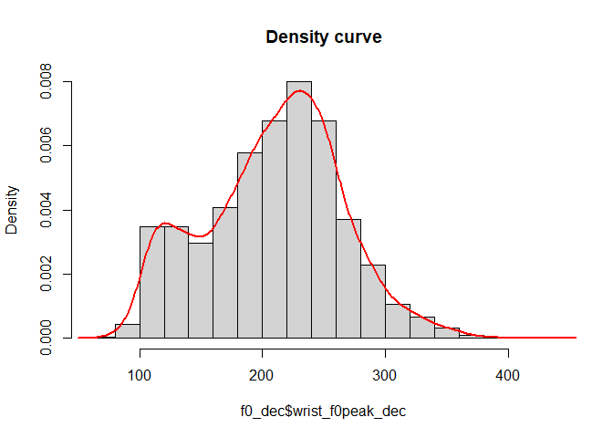

```r
# This distribution, especially the red line will be the one we will later see in the posterior predictive checks as y
hist(f0_dec$wrist_f0peak_dec, freq = FALSE, main = "Density curve")
lines(density(na.omit(f0_dec$wrist_f0peak_dec)), lwd = 2, col = 'red')
```

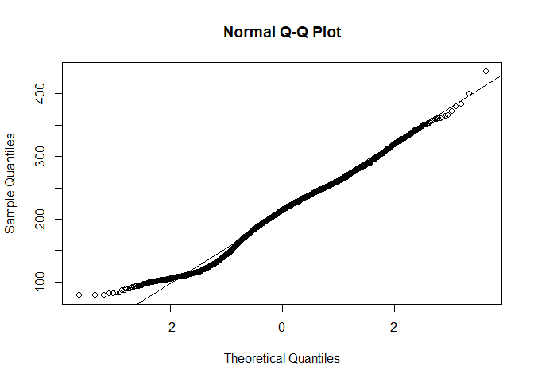

```r
qqnorm(f0_dec$wrist_f0peak_dec)
qqline(f0_dec$wrist_f0peak_dec)
```

```r
shapiro.test(f0_dec$wrist_f0peak_dec)
```

```
##
##  Shapiro-Wilk normality test
##
## data:  f0_dec$wrist_f0peak_dec
## W = 0.98694, p-value < 2.2e-16
```

```r
ks.test(f0_dec$wrist_f0peak_dec, 'pnorm')
```

```
##
##  Asymptotic one-sample Kolmogorov-Smirnov test
##
## data:  f0_dec$wrist_f0peak_dec
## D = 1, p-value < 2.2e-16
## alternative hypothesis: two-sided
```

The outcome variable is not normally distributed.

Now, let’s check for correlation between speech rate and wrist deceleration peak. We use two methods: Bayesian and frequentist.

```r
# Bayes factor
f0dec_corr_s <- correlationBF(f0_dec$speech_rate_s, f0_dec$wrist_decpeak)
describe_posterior(f0dec_corr_s)
```

```
## Summary of Posterior Distribution
##
## Parameter | Median |         95% CI |   pd |          ROPE | % in ROPE
## ----------------------------------------------------------------------
## rho       |  -0.10 | [-0.13, -0.07] | 100% | [-0.05, 0.05] |        0%
##
## Parameter |       BF |         Prior
## ------------------------------------
## rho       | 1.30e+06 | Beta (3 +- 3)
```

```r
bayesfactor(f0dec_corr_s)
```

```
## Bayes Factors for Model Comparison
##
##     Model            BF
## [2] (rho != 0) 1.30e+06
##
## * Against Denominator: [1] (rho = 0)
## *   Bayes Factor Type: JZS (BayesFactor)
```

```r
# Frequentist Kendall
cor(f0_dec$speech_rate_s, f0_dec$wrist_decpeak)
```

```
## [1] -0.09811341
```

```r
cor.test(f0_dec$speech_rate_s, f0_dec$wrist_decpeak,  method="kendall")
```

```
##
##  Kendall's rank correlation tau
##
## data:  f0_dec$speech_rate_s and f0_dec$wrist_decpeak
## z = -25.813, p-value < 2.2e-16
## alternative hypothesis: true tau is not equal to 0
## sample estimates:
##        tau
## -0.3519596
```

Bayes factor points to a very strong evidence for a correlation.

We set weakly informative priors. Like with acceleration, we truncate the intercept prior to include only positive values, with the lowest point to be 70 Hz. Any lower values would be erroneous octave jumps and they were discarded in the pre-processing.

```r
get_prior(
  wrist_f0peak_dec ~ 1 +
    speech_rate_s +
    point_direct_s +
    wrist_decpeak +
    sex_s +
    point_direct_s * wrist_decpeak +
    (1 | speaker) +
    (0 + speech_rate_s + point_direct_s + wrist_decpeak + point_direct_s * wrist_decpeak | speaker) +
    (1 | rhyme) +
    (0 + speech_rate_s + point_direct_s + wrist_decpeak + sex_s + point_direct_s * wrist_decpeak | rhyme),
  data = f0_dec,
  family = "gaussian"
)

prior1 <- set_prior("truncated_normal(0, 200, lower = 70)", class = "Intercept")
prior2 <- set_prior("normal(0, 75)", class = "b", coef = "sex_s")
prior3 <- set_prior("normal(0, 10)", class = "b", coef = "point_direct_s")
prior4 <- set_prior("normal(0, 1)", class = "b", coef = "point_direct_s:wrist_decpeak")
prior5 <- set_prior("normal(0, 10)", class = "b", coef = "speech_rate_s")
prior6 <- set_prior("normal(0, 1)", class = "b", coef = "wrist_decpeak")
prior7 <- set_prior("normal(0, 100)", class = "sd")
prior8 <- set_prior("normal(0, 100)", class = "sigma")
prior9 <- set_prior("lkj(2)", class = "cor")
priors_f0_dec <- list(prior1, prior2, prior3, prior4, prior5, prior6, prior7, prior8, prior9)
priors_f0_dec <- prior_summary(priors_f0_dec)
```

### Gaussian + priors

This is the model code.

```r
f0peak_dec <- brm(
  wrist_f0peak_dec ~ 1 +
    speech_rate_s +
    point_direct_s +
    wrist_decpeak +
    sex_s +
    point_direct_s * wrist_decpeak +
    (1 | speaker) +
    (0 + speech_rate_s + point_direct_s + wrist_decpeak + point_direct_s * wrist_decpeak || speaker) +
    (1 | rhyme) +
    (0 + speech_rate_s + point_direct_s + wrist_decpeak + sex_s + point_direct_s * wrist_decpeak || rhyme),
  data = f0_dec,
  family = "gaussian",
  prior = priors_f0_dec,
  # Technical stuff
  backend = "cmdstanr",
  # Number of chains
  chains = 4,
  # Number of iterations per chain
  iter = 10000,
  warmup = 2000,
  # Number of cores to use
  cores = 4,
  # Seed for replicability
  seed = 123,
  # Convergence
  control = list(adapt_delta = 0.99),
  # Save here
  file = paste0(parentfolder, "/9_statistical_analysis_scripts_and_model_output/f0peak_dec_new.rds"))
```

Load ready model:

```r
f0peak_dec = readRDS(paste0(parentfolder, "/9_statistical_analysis_scripts_and_model_output/f0peak_dec_new.rds"))
```

### Output

Look at model output and model fit using posterior predictive checks.

```r
f0peak_dec_pp <- pp_check(f0peak_dec, ndraws = 1000)

# This is the model output
f0peak_dec
```

```
##  Family: gaussian
##   Links: mu = identity
## Formula: wrist_f0peak_dec ~ 1 + speech_rate_s + point_direct_s + wrist_decpeak + sex_s + point_direct_s * wrist_decpeak + (1 | speaker) + (0 + speech_rate_s + point_direct_s + wrist_decpeak + point_direct_s * wrist_decpeak || speaker) + (1 | rhyme) + (0 + speech_rate_s + point_direct_s + wrist_de…
##    Data: f0_dec (Number of observations: 3398)
##   Draws: 4 chains, each with iter = 10000; warmup = 2000; thin = 1;
##          total post-warmup draws = 32000
##
## Multilevel Hyperparameters:
## ~rhyme (Number of levels: 6)
##                                  Estimate Est.Error l-95% CI u-95% CI Rhat
## sd(Intercept)                        1.85      1.61     0.07     5.92 1.00
## sd(speech_rate_s)                    1.55      1.55     0.05     5.36 1.00
## sd(point_direct_s)                   2.83      2.62     0.11     9.36 1.00
## sd(wrist_decpeak)                    0.23      0.20     0.01     0.73 1.00
## sd(sex_s)                            2.74      2.53     0.10     9.16 1.00
## sd(point_direct_s:wrist_decpeak)     0.32      0.31     0.01     1.08 1.00
##                                  Bulk_ESS Tail_ESS
## sd(Intercept)                       12241    16047
## sd(speech_rate_s)                   18504    16398
## sd(point_direct_s)                  12685    16493
## sd(wrist_decpeak)                   13371    16321
## sd(sex_s)                           12822    15413
## sd(point_direct_s:wrist_decpeak)    15048    17967
##
## ~speaker (Number of levels: 11)
##                                  Estimate Est.Error l-95% CI u-95% CI Rhat
## sd(Intercept)                       24.61      6.92    14.91    41.75 1.00
## sd(speech_rate_s)                    5.06      2.48     0.78    10.66 1.00
## sd(point_direct_s)                   2.53      1.94     0.10     7.30 1.00
## sd(wrist_decpeak)                    0.70      0.44     0.04     1.71 1.00
## sd(point_direct_s:wrist_decpeak)     0.37      0.29     0.02     1.07 1.00
##                                  Bulk_ESS Tail_ESS
## sd(Intercept)                       10868    17247
## sd(speech_rate_s)                    8519     8734
## sd(point_direct_s)                  11531    14711
## sd(wrist_decpeak)                   10143    12615
## sd(point_direct_s:wrist_decpeak)    10517    15358
##
## Regression Coefficients:
##                              Estimate Est.Error l-95% CI u-95% CI Rhat Bulk_ESS
## Intercept                      172.89      8.77   155.36   190.28 1.00    12252
## speech_rate_s                    3.72      2.35    -0.93     8.40 1.00    19304
## point_direct_s                   1.14      3.49    -5.73     7.91 1.00    23803
## wrist_decpeak                   -0.91      0.39    -1.68    -0.13 1.00    21936
## sex_s                           98.67     17.44    63.52   133.03 1.00    10531
## point_direct_s:wrist_decpeak    -0.00      0.47    -0.92     0.91 1.00    24437
##                              Tail_ESS
## Intercept                       16597
## speech_rate_s                   20136
## point_direct_s                  22331
## wrist_decpeak                   21332
## sex_s                           15408
## point_direct_s:wrist_decpeak    20814
##
## Further Distributional Parameters:
##       Estimate Est.Error l-95% CI u-95% CI Rhat Bulk_ESS Tail_ESS
## sigma    31.33      0.38    30.60    32.09 1.00    54526    23088
##
## Draws were sampled using sample(hmc). For each parameter, Bulk_ESS
## and Tail_ESS are effective sample size measures, and Rhat is the potential
## scale reduction factor on split chains (at convergence, Rhat = 1).
```

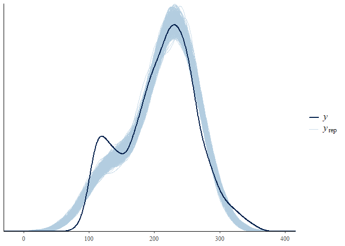

```r
# These are the posterior predictive checks with 1000 samples.
f0peak_dec_pp
```

```r
#ggsave(file.path(plots, "f0peak_dec_pp.pdf"), plot = f0peak_dec_pp, width = 7, height = 4)
```

```
## Ignoring unknown labels:
## • fill : "NA"
## • colour : "NA"
## Ignoring unknown labels:
## • fill : "NA"
## • colour : "NA"
```

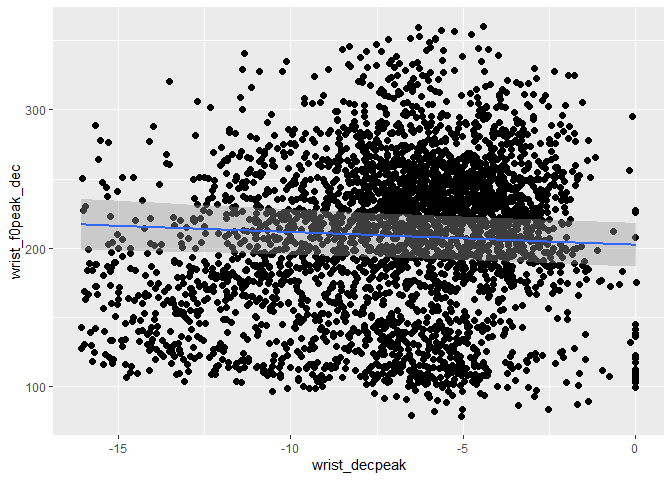

```r
plot(conditional_effects(f0peak_dec, effects = "wrist_decpeak"), points = TRUE)
```

The fit is not ideal, since it includes an additional “bump.” **Please see supplementary info for more information.** But we see that the posteriors generally follow the distribution, just like with acceleration.

Now we run some diagnostics.

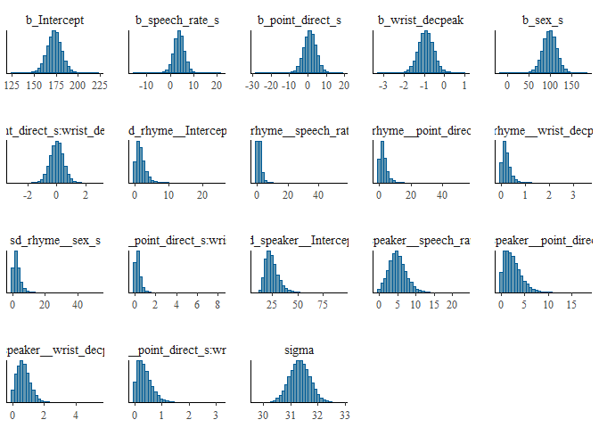

```r
mcmc_plot(f0peak_dec, type="hist")
```

```r
# Please uncomment and run this if you want to see the shinystan GUI and explore the model.
# shiny_f0peak_dec <- launch_shinystan(f0peak_dec)
```

Compute posterior probability of all predictors.

```r
posteriors_f0dec <- posterior_samples(f0peak_dec)
sum(posteriors_f0dec$b_speech_rate_s > 0) / nrow(posteriors_f0dec) # 0.9784687
```

```
## [1] 0.9469688
```

```r
sum(posteriors_f0dec$b_point_direct_s < 0) / nrow(posteriors_f0dec) # 0.7204687
```

```
## [1] 0.364375
```

```r
sum(posteriors_f0dec$b_wrist_decpeak < 0) / nrow(posteriors_f0dec) # 0.7805937
```

```
## [1] 0.9866875
```

```r
sum(posteriors_f0dec$b_sex_s > 0) / nrow(posteriors_f0dec) # 0.9999687
```

```
## [1] 0.9999062
```

```r
sum(posteriors_f0dec[,6] < 0) / nrow(posteriors_f0dec) # interaction 0.8067188
```

```
## [1] 0.5011875
```

## Envelope Acceleration

### Preparation

Check for normality of the outcome variable: amplitude envelope peak nearest to acceleration peak.

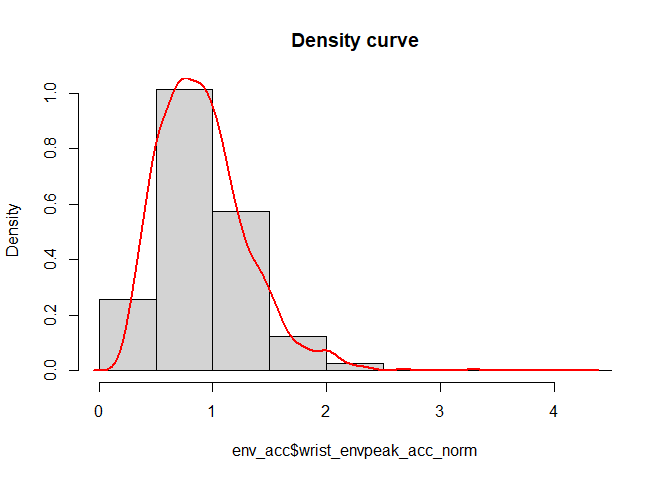

```r
# This distribution, especially the red line will be the one we will later see in the posterior predictive checks as y
hist(env_acc$wrist_envpeak_acc_norm, freq = FALSE, main = "Density curve")
lines(density(na.omit(env_acc$wrist_envpeak_acc_norm)), lwd = 2, col = 'red')
```

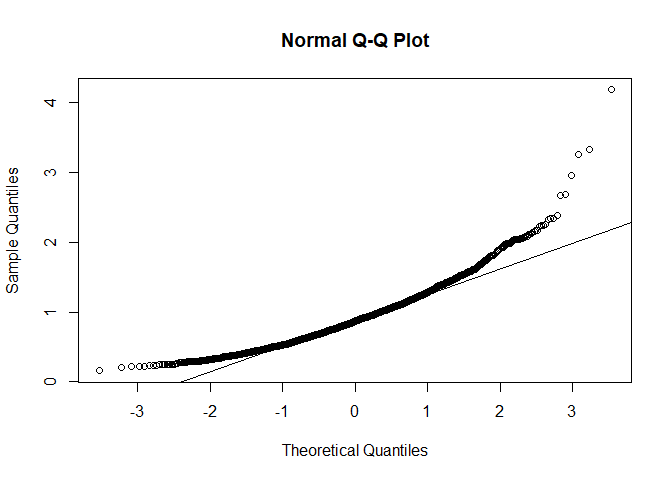

```r
qqnorm(env_acc$wrist_envpeak_acc_norm)
qqline(env_acc$wrist_envpeak_acc_norm)
```

```r
shapiro.test(env_acc$wrist_envpeak_acc_norm) # the data is not normally distributed
```

```
##
##  Shapiro-Wilk normality test
##
## data:  env_acc$wrist_envpeak_acc_norm
## W = 0.94132, p-value < 2.2e-16
```

```r
ks.test(env_acc$wrist_envpeak_acc_norm, 'pnorm') # also not normally distributed
```

```
##
##  Asymptotic one-sample Kolmogorov-Smirnov test
##
## data:  env_acc$wrist_envpeak_acc_norm
## D = 0.60444, p-value < 2.2e-16
## alternative hypothesis: two-sided
```

The outcome variable is not normally distributed.

We also check the correlations, like above.

```r
# Bayes factor
envacc_corr_s <- correlationBF(env_acc$speech_rate_s, env_acc$wrist_apeak)
describe_posterior(envacc_corr_s)
```

```
## Summary of Posterior Distribution
##
## Parameter | Median |       95% CI |   pd |          ROPE | % in ROPE |       BF |         Prior
## -----------------------------------------------------------------------------------------------
## rho       |   0.10 | [0.06, 0.14] | 100% | [-0.05, 0.05] |        0% | 1.20e+04 | Beta (3 +- 3)
```

```r
bayesfactor(envacc_corr_s)
```

```
## Bayes Factors for Model Comparison
##
##     Model            BF
## [2] (rho != 0) 1.20e+04
##
## * Against Denominator: [1] (rho = 0)
## *   Bayes Factor Type: JZS (BayesFactor)
```

```r
# Frequentist Kendall
cor(env_acc$speech_rate_s, env_acc$wrist_apeak)
```

```
## [1] 0.1007287
```

```r
cor.test(env_acc$speech_rate_s, env_acc$wrist_apeak, method = "kendall")
```

```
##
##  Kendall's rank correlation tau
##
## data:  env_acc$speech_rate_s and env_acc$wrist_apeak
## z = 23.515, p-value < 2.2e-16
## alternative hypothesis: true tau is not equal to 0
## sample estimates:
##       tau
## 0.3882203
```

Bayes factor points to a very strong evidence for a correlation.

We set weakly informative priors. We truncate the intercept prior to include only positive values, with the lowest point to be 0. Any lower values would be erroneous and they were discarded in the pre-processing.

```r
get_prior(
  wrist_envpeak_acc_norm ~ 1 +
    speech_rate_s +
    point_direct_s +
    wrist_apeak +
    sex_s +
    point_direct_s * wrist_apeak +
    (1 | speaker) +
    (0 + speech_rate_s + point_direct_s + wrist_apeak + point_direct_s * wrist_apeak | speaker) +
    (1 | rhyme) +
    (0 + speech_rate_s + point_direct_s + wrist_apeak + sex_s + point_direct_s * wrist_apeak | rhyme),
  data = env_acc,
  family = "gaussian"
)

prior1 <- set_prior("truncated_normal(0, 5, lower = 0)", class = "Intercept")
prior2 <- set_prior("normal(0, 1)", class = "b", coef = "sex_s")
prior3 <- set_prior("normal(0, 1)", class = "b", coef = "point_direct_s")
prior4 <- set_prior("normal(0, 0.1)", class = "b", coef = "point_direct_s:wrist_apeak")
prior5 <- set_prior("normal(0, 1)", class = "b", coef = "speech_rate_s")
prior6 <- set_prior("normal(0, 0.1)", class = "b", coef = "wrist_apeak")
prior7 <- set_prior("normal(0, 2.5)", class = "sd")
prior8 <- set_prior("normal(0, 2.5)", class = "sigma")
prior9 <- set_prior("lkj(2)", class = "cor")
priors_env_acc <- list(prior1, prior2, prior3, prior4, prior5, prior6, prior7, prior8, prior9)
priors_env_acc <- prior_summary(priors_env_acc)
```

#### Gaussian + priors

This is the model code.

```r
envpeak_acc <- brm(
  wrist_envpeak_acc_norm ~ 1 +
    speech_rate_s +
    point_direct_s +
    wrist_apeak +
    sex_s +
    point_direct_s * wrist_apeak +
    (1 | speaker) +
    (0 + speech_rate_s + point_direct_s + wrist_apeak + point_direct_s * wrist_apeak || speaker) +
    (1 | rhyme) +
    (0 + speech_rate_s + point_direct_s + wrist_apeak + sex_s + point_direct_s * wrist_apeak || rhyme),
  data = env_acc,
  family = "gaussian",
  prior = priors_env_acc,
  # Technical stuff
  backend = "cmdstanr",
  # Number of chains
  chains = 4,
  # Number of iterations per chain
  iter = 10000,
  warmup = 2000,
  # Number of cores to use
  cores = 4,
  # Seed for replicability
  seed = 42,
  # Convergence
  control = list(adapt_delta = 0.999),
  max_treedepth = 12,
  # Save here
  file = paste0(parentfolder, "/9_statistical_analysis_scripts_and_model_output/envpeak_acc_new.rds"))
```

Load ready model:

```r
envpeak_acc = readRDS(paste0(parentfolder, "/9_statistical_analysis_scripts_and_model_output/envpeak_acc_new.rds"))
```

### Output

Look at model output and model fit using posterior predictive checks.

```r
envpeak_acc_pp <- pp_check(envpeak_acc, ndraws = 1000)

# This is the model output
envpeak_acc
```

```
##  Family: gaussian
##   Links: mu = identity
## Formula: wrist_envpeak_acc_norm ~ 1 + speech_rate_s + point_direct_s + wrist_apeak + sex_s + point_direct_s * wrist_apeak + (1 | speaker) + (0 + speech_rate_s + point_direct_s + wrist_apeak + point_direct_s * wrist_apeak || speaker) + (1 | rhyme) + (0 + speech_rate_s + point_direct_s + wrist_apea…
##    Data: env_acc (Number of observations: 2290)
##   Draws: 4 chains, each with iter = 10000; warmup = 2000; thin = 1;
##          total post-warmup draws = 32000
##
## Multilevel Hyperparameters:
## ~rhyme (Number of levels: 6)
##                                Estimate Est.Error l-95% CI u-95% CI Rhat
## sd(Intercept)                      0.06      0.04     0.01     0.16 1.00
## sd(speech_rate_s)                  0.03      0.03     0.00     0.10 1.00
## sd(point_direct_s)                 0.04      0.04     0.00     0.14 1.00
## sd(wrist_apeak)                    0.01      0.01     0.00     0.02 1.00
## sd(sex_s)                          0.04      0.04     0.00     0.13 1.00
## sd(point_direct_s:wrist_apeak)     0.01      0.01     0.00     0.03 1.00
##                                Bulk_ESS Tail_ESS
## sd(Intercept)                     12628    12530
## sd(speech_rate_s)                 12274    17323
## sd(point_direct_s)                13213    16335
## sd(wrist_apeak)                   11091    14922
## sd(sex_s)                         13095    14893
## sd(point_direct_s:wrist_apeak)    10338    15060
##
## ~speaker (Number of levels: 11)
##                                Estimate Est.Error l-95% CI u-95% CI Rhat
## sd(Intercept)                      0.03      0.02     0.00     0.09 1.00
## sd(speech_rate_s)                  0.23      0.06     0.14     0.39 1.00
## sd(point_direct_s)                 0.12      0.04     0.06     0.21 1.00
## sd(wrist_apeak)                    0.01      0.01     0.00     0.02 1.00
## sd(point_direct_s:wrist_apeak)     0.01      0.01     0.00     0.02 1.00
##                                Bulk_ESS Tail_ESS
## sd(Intercept)                      9094    13044
## sd(speech_rate_s)                 12035    17748
## sd(point_direct_s)                13124    19715
## sd(wrist_apeak)                    7922     8976
## sd(point_direct_s:wrist_apeak)    12181    15417
##
## Regression Coefficients:
##                            Estimate Est.Error l-95% CI u-95% CI Rhat Bulk_ESS
## Intercept                      0.78      0.04     0.70     0.86 1.00    24551
## speech_rate_s                 -0.10      0.08    -0.25     0.05 1.00     8810
## point_direct_s                -0.07      0.06    -0.18     0.05 1.00    19082
## wrist_apeak                    0.02      0.01     0.00     0.03 1.00    18892
## sex_s                          0.03      0.05    -0.08     0.13 1.00    19573
## point_direct_s:wrist_apeak     0.01      0.01    -0.01     0.02 1.00    28340
##                            Tail_ESS
## Intercept                     22241
## speech_rate_s                 14404
## point_direct_s                20865
## wrist_apeak                   19467
## sex_s                         19928
## point_direct_s:wrist_apeak    22912
##
## Further Distributional Parameters:
##       Estimate Est.Error l-95% CI u-95% CI Rhat Bulk_ESS Tail_ESS
## sigma     0.31      0.00     0.30     0.32 1.00    50408    22776
##
## Draws were sampled using sample(hmc). For each parameter, Bulk_ESS
## and Tail_ESS are effective sample size measures, and Rhat is the potential
## scale reduction factor on split chains (at convergence, Rhat = 1).
```

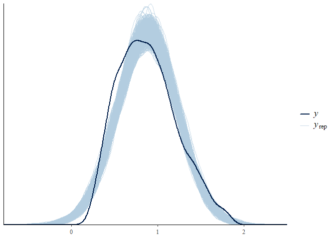

```r
# These are the posterior predictive checks with 1000 samples.
envpeak_acc_pp
```

```r
#ggsave(file.path(plots, "envpeak_acc_pp.pdf"), plot = envpeak_acc_pp, width = 7, height = 4)
```

The fit is quite good, although there are some instances where y_rep doesn’t overlap with y.

```
## Ignoring unknown labels:
## • fill : "NA"
## • colour : "NA"
## Ignoring unknown labels:
## • fill : "NA"
## • colour : "NA"
```

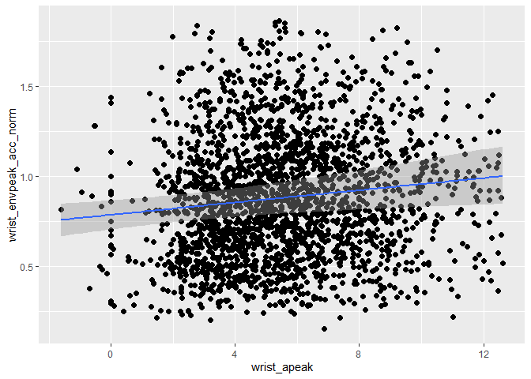

```r
plot(conditional_effects(envpeak_acc, effects = "wrist_apeak"), points = TRUE)
```

Let’s run further diagnostics.

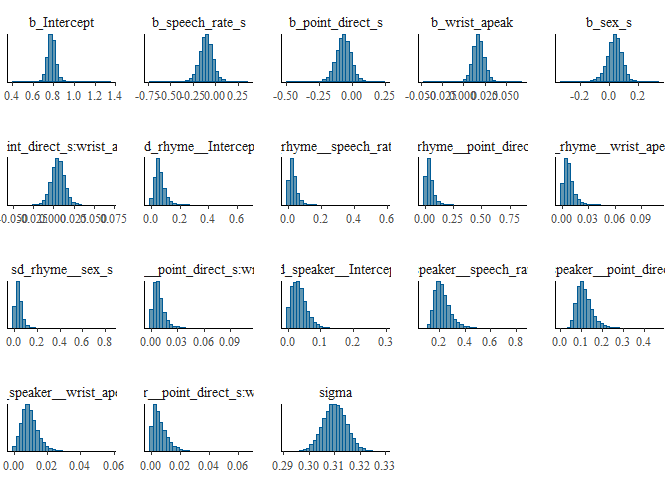

```r
mcmc_plot(envpeak_acc, type="hist")
```

```r
# Please uncomment and run this if you want to see the shinystan GUI and explore the model.
# shiny_envpeak_acc <- launch_shinystan(envpeak_acc)
```

Compute posterior probability of all predictors.

```r
posteriors_mdl_env_acc <- posterior_samples(envpeak_acc)
sum(posteriors_mdl_env_acc$b_speech_rate_s < 0) / nrow(posteriors_mdl_env_acc) # 0.8616563
```

```
## [1] 0.9237812
```

```r
sum(posteriors_mdl_env_acc$b_point_direct_s < 0) / nrow(posteriors_mdl_env_acc) # 0.8878438
```

```
## [1] 0.8871875
```

```r
sum(posteriors_mdl_env_acc$b_wrist_apeak > 0) / nrow(posteriors_mdl_env_acc) # 0.9010625
```

```
## [1] 0.9923125
```

```r
sum(posteriors_mdl_env_acc$b_sex_s > 0) / nrow(posteriors_mdl_env_acc) # 0.8140312
```

```
## [1] 0.764375
```

```r
sum(posteriors_mdl_env_acc[,6] > 0) / nrow(posteriors_mdl_env_acc) # interaction 0.7585625
```

```
## [1] 0.744875
```

## Envelope Deceleration

#### Preparation

Check for normality of the outcome variable: amplitude envelope peak nearest to deceleration peak.

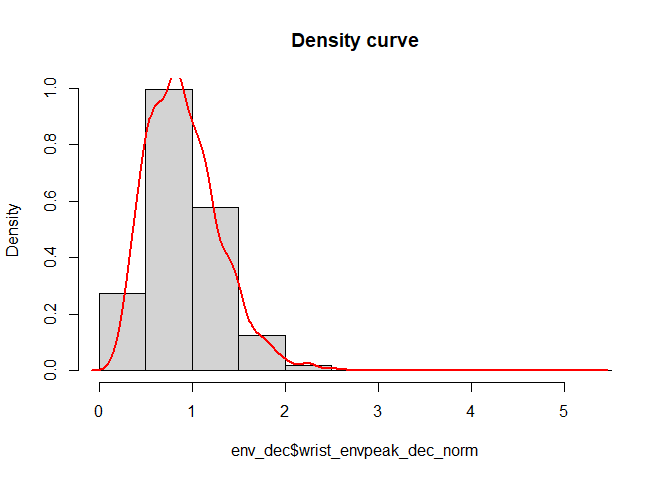

```r
# This distribution, especially the red line will be the one we will later see in the posterior predictive checks as y
hist(env_dec$wrist_envpeak_dec_norm, freq = FALSE, main = "Density curve")
lines(density(na.omit(env_dec$wrist_envpeak_dec_norm)), lwd = 2, col = 'red')
```

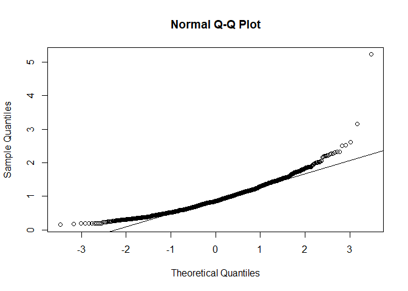

```r
qqnorm(env_dec$wrist_envpeak_dec_norm)
qqline(env_dec$wrist_envpeak_dec_norm) # not normal
```

```r
shapiro.test(env_dec$wrist_envpeak_dec_norm) # the data is not normally distributed
```

```
##
##  Shapiro-Wilk normality test
##
## data:  env_dec$wrist_envpeak_dec_norm
## W = 0.93613, p-value < 2.2e-16
```

```r
ks.test(env_dec$wrist_envpeak_dec_norm, 'pnorm') # also not normally distributed
```

```
##
##  Asymptotic one-sample Kolmogorov-Smirnov test
##
## data:  env_dec$wrist_envpeak_dec_norm
## D = 0.60054, p-value < 2.2e-16
## alternative hypothesis: two-sided
```

The outcome variable is not normally distributed.

Now, let’s check for correlation between speech rate and wrist deceleration peak.

```r
# Bayes factor
envdec_corr_s <- correlationBF(env_dec$speech_rate_s, env_dec$wrist_decpeak)
describe_posterior(envdec_corr_s)
```

```
## Summary of Posterior Distribution
##
## Parameter | Median |         95% CI |   pd |          ROPE | % in ROPE |     BF |         Prior
## -----------------------------------------------------------------------------------------------
## rho       |  -0.10 | [-0.14, -0.05] | 100% | [-0.05, 0.05] |        0% | 394.63 | Beta (3 +- 3)
```

```r
bayesfactor(envdec_corr_s)
```

```
## Bayes Factors for Model Comparison
##
##     Model          BF
## [2] (rho != 0) 394.63
##
## * Against Denominator: [1] (rho = 0)
## *   Bayes Factor Type: JZS (BayesFactor)
```

```r
# Frequentist Kendall
cor(env_dec$speech_rate_s, env_dec$wrist_decpeak)
```

```
## [1] -0.09586416
```

```r
cor.test(env_dec$speech_rate_s, env_dec$wrist_decpeak, method = "kendall")
```

```
##
##  Kendall's rank correlation tau
##
## data:  env_dec$speech_rate_s and env_dec$wrist_decpeak
## z = -19.696, p-value < 2.2e-16
## alternative hypothesis: true tau is not equal to 0
## sample estimates:
##        tau
## -0.3654977
```

Bayes factor points to a very strong evidence for a correlation.

We set weakly informative priors. We truncate the intercept prior to include only positive values, with the lowest point to be 0, like in the env acc model.

```r
get_prior(
  wrist_envpeak_dec_norm ~ 1 +
    speech_rate_s +
    point_direct_s +
    wrist_apeak +
    sex_s +
    point_direct_s * wrist_apeak +
    (1 | speaker) +
    (0 + speech_rate_s + point_direct_s + wrist_apeak + point_direct_s * wrist_apeak | speaker) +
    (1 | rhyme) +
    (0 + speech_rate_s + point_direct_s + wrist_apeak + sex_s + point_direct_s * wrist_apeak | rhyme),
  data = env_dec,
  family = "gaussian"
)

prior1 <- set_prior("truncated_normal(0, 5, lower = 0)", class = "Intercept")
prior2 <- set_prior("normal(0, 1)", class = "b", coef = "sex_s")
prior3 <- set_prior("normal(0, 1)", class = "b", coef = "point_direct_s")
prior4 <- set_prior("normal(0, 0.1)", class = "b", coef = "point_direct_s:wrist_apeak")
prior5 <- set_prior("normal(0, 1)", class = "b", coef = "speech_rate_s")
prior6 <- set_prior("normal(0, 0.1)", class = "b", coef = "wrist_decpeak")
prior7 <- set_prior("normal(0, 2.5)", class = "sd")
prior8 <- set_prior("normal(0, 2.5)", class = "sigma")
prior9 <- set_prior("lkj(2)", class = "cor")
priors_env_dec <- list(prior1, prior2, prior3, prior4, prior5, prior6, prior7, prior8, prior9)
priors_env_dec <- prior_summary(priors_env_dec)
```

#### Gaussian + priors

Load ready model:

```r
envpeak_dec = readRDS(paste0(parentfolder, "/9_statistical_analysis_scripts_and_model_output/envpeak_dec_new.rds"))
```

### Output

Look at model output and model fit using posterior predictive checks.

```r
envpeak_dec_pp <- pp_check(envpeak_dec, ndraws = 1000)

# This is the model output
envpeak_dec
```

```
##  Family: gaussian
##   Links: mu = identity
## Formula: wrist_envpeak_dec_norm ~ 1 + speech_rate_s + point_direct_s + wrist_decpeak + sex_s + point_direct_s * wrist_decpeak + (1 | speaker) + (0 + speech_rate_s + point_direct_s + wrist_decpeak + point_direct_s * wrist_decpeak || speaker) + (1 | rhyme) + (0 + speech_rate_s + point_direct_s + wr…
##    Data: env_dec (Number of observations: 1829)
##   Draws: 4 chains, each with iter = 10000; warmup = 2000; thin = 1;
##          total post-warmup draws = 32000
##
## Multilevel Hyperparameters:
## ~rhyme (Number of levels: 6)
##                                  Estimate Est.Error l-95% CI u-95% CI Rhat
## sd(Intercept)                        0.10      0.06     0.04     0.26 1.00
## sd(speech_rate_s)                    0.04      0.03     0.00     0.12 1.00
## sd(point_direct_s)                   0.03      0.03     0.00     0.11 1.00
## sd(wrist_decpeak)                    0.01      0.01     0.00     0.02 1.00
## sd(sex_s)                            0.04      0.04     0.00     0.14 1.00
## sd(point_direct_s:wrist_decpeak)     0.00      0.00     0.00     0.01 1.00
##                                  Bulk_ESS Tail_ESS
## sd(Intercept)                       10362    16552
## sd(speech_rate_s)                   11336    14678
## sd(point_direct_s)                  14785    17112
## sd(wrist_decpeak)                    9321    14770
## sd(sex_s)                           14253    16150
## sd(point_direct_s:wrist_decpeak)    14663    16301
##
## ~speaker (Number of levels: 11)
##                                  Estimate Est.Error l-95% CI u-95% CI Rhat
## sd(Intercept)                        0.05      0.03     0.01     0.13 1.00
## sd(speech_rate_s)                    0.25      0.07     0.15     0.42 1.00
## sd(point_direct_s)                   0.06      0.03     0.00     0.13 1.00
## sd(wrist_decpeak)                    0.01      0.00     0.00     0.02 1.00
## sd(point_direct_s:wrist_decpeak)     0.01      0.00     0.00     0.02 1.00
##                                  Bulk_ESS Tail_ESS
## sd(Intercept)                        8615    10756
## sd(speech_rate_s)                   11112    16725
## sd(point_direct_s)                   9355    12313
## sd(wrist_decpeak)                    8809     9290
## sd(point_direct_s:wrist_decpeak)    12115    15454
##
## Regression Coefficients:
##                              Estimate Est.Error l-95% CI u-95% CI Rhat Bulk_ESS
## Intercept                        0.68      0.06     0.56     0.80 1.00    18895
## speech_rate_s                   -0.16      0.08    -0.33     0.00 1.00     8349
## point_direct_s                  -0.01      0.05    -0.11     0.09 1.00    25506
## wrist_decpeak                   -0.03      0.01    -0.04    -0.02 1.00    19859
## sex_s                            0.07      0.06    -0.06     0.19 1.00    21507
## point_direct_s:wrist_decpeak    -0.00      0.01    -0.02     0.01 1.00    29309
##                              Tail_ESS
## Intercept                       18850
## speech_rate_s                   14446
## point_direct_s                  21804
## wrist_decpeak                   16533
## sex_s                           18625
## point_direct_s:wrist_decpeak    23862
##
## Further Distributional Parameters:
##       Estimate Est.Error l-95% CI u-95% CI Rhat Bulk_ESS Tail_ESS
## sigma     0.33      0.01     0.32     0.34 1.00    47019    24221
##
## Draws were sampled using sample(hmc). For each parameter, Bulk_ESS
## and Tail_ESS are effective sample size measures, and Rhat is the potential
## scale reduction factor on split chains (at convergence, Rhat = 1).
```

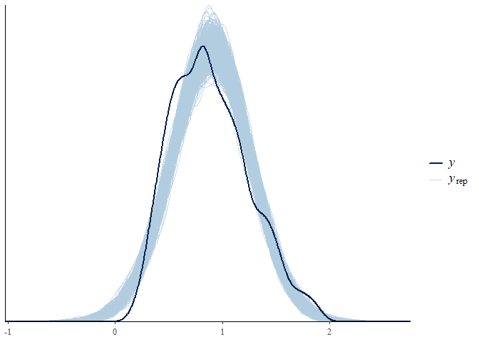

```r
# These are the posterior predictive checks with 1000 samples.
envpeak_dec_pp
```

```r
#ggsave(file.path(plots, "envpeak_dec_pp.pdf"), plot = envpeak_dec_pp, width = 7, height = 4)
```

We have a reliable effect of wrist deceleration peak.

```
## Ignoring unknown labels:
## • fill : "NA"
## • colour : "NA"
## Ignoring unknown labels:
## • fill : "NA"
## • colour : "NA"
```

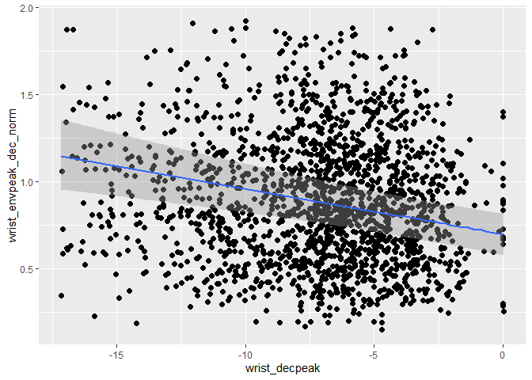

```r
plot(conditional_effects(envpeak_dec, effects = "wrist_decpeak"), points = TRUE)
```

The fit is similar to env acc.

Now we run some diagnostics.

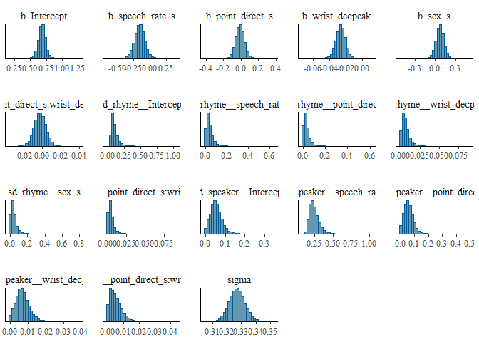

```r
mcmc_plot(envpeak_dec, type="hist")
```

```r
# Please uncomment and run this if you want to see the shinystan GUI and explore the model.
# shiny_envpeak_dec <- launch_shinystan(envpeak_dec)
```

Compute posterior probability of all predictors.

```r
posteriors_mdl_env_dec <- posterior_samples(envpeak_dec)
sum(posteriors_mdl_env_dec$b_speech_rate_s < 0) / nrow(posteriors_mdl_env_dec) # 0.973875
```

```
## [1] 0.973875
```

```r
sum(posteriors_mdl_env_dec$b_point_direct_s < 0) / nrow(posteriors_mdl_env_dec) #  0.5802812
```

```
## [1] 0.5802812
```

```r
sum(posteriors_mdl_env_dec$b_wrist_decpeak < 0) / nrow(posteriors_mdl_env_dec) # 0.9994375
```

```
## [1] 0.9994375
```

```r
sum(posteriors_mdl_env_dec$b_sex_s > 0) / nrow(posteriors_mdl_env_dec) # 0.8771875
```

```
## [1] 0.8771875
```

```r
sum(posteriors_mdl_env_dec[,6] < 0) / nrow(posteriors_mdl_env_dec) # interaction 0.6679375
```

```
## [1] 0.6679375
```

Compare acceleration and deceleration values

```r
peak_summary <- function(df, var, name) {
  x <- df[[var]]
  data.frame(dataset = name, peak = var,
             n = sum(!is.na(x)),
             mean = mean(x, na.rm = TRUE),
             mean_abs = mean(abs(x), na.rm = TRUE),
             sd = sd(x, na.rm = TRUE),
             median_abs = median(abs(x), na.rm = TRUE))
}

peaks <- rbind(
  peak_summary(f0_acc,  "wrist_apeak",   "f0_acc"),
  peak_summary(env_acc, "wrist_apeak",   "env_acc"),
  peak_summary(f0_dec,  "wrist_decpeak", "f0_dec"),
  peak_summary(env_dec, "wrist_decpeak", "env_dec")
)
peaks[, 3:7] <- round(peaks[, 3:7], 2)
peaks
```

```
##   dataset          peak    n   mean mean_abs    sd median_abs
## 1  f0_acc   wrist_apeak 3570   8.88     8.96 32.88       5.27
## 2 env_acc   wrist_apeak 2448   8.15     8.21 28.26       5.40
## 3  f0_dec wrist_decpeak 3588 -10.56    10.57 31.89       6.67
## 4 env_dec wrist_decpeak 1938 -10.52    10.52 30.48       6.81
```

Compare the two deceleration models

```r
# exact estimates, no rounding
fixef(f0peak_dec)["wrist_decpeak", ]
```

```
##   Estimate  Est.Error       Q2.5      Q97.5
## -0.9107018  0.3910473 -1.6772264 -0.1327803
```

```r
fixef(envpeak_dec)["wrist_decpeak", ]
```

```
##     Estimate    Est.Error         Q2.5        Q97.5
## -0.026258240  0.005959269 -0.038467554 -0.015189390
```

```r
dr_f0  <- as_draws_df(f0peak_dec)
dr_env <- as_draws_df(envpeak_dec)
b_f0   <- -dr_f0$b_wrist_decpeak    # minus: positive = stronger deceleration -> higher outcome
b_env  <- -dr_env$b_wrist_decpeak

summ <- function(x) round(c(mean = mean(x), quantile(x, c(.025, .975))), 3)

# 1. certainty: how many posterior SDs from zero (unit-free)
c(f0 = mean(b_f0) / sd(b_f0), env = mean(b_env) / sd(b_env))
```

```
##       f0      env
## 2.328879 4.406285
```

```r
# 2. size: % change of the outcome per 1 cm/s^2 stronger deceleration
rel_f0  <- b_f0  / mean(f0peak_dec$data$wrist_f0peak_dec)        * 100
rel_env <- b_env / mean(envpeak_dec$data$wrist_envpeak_dec_norm) * 100
rbind(f0 = summ(rel_f0), env = summ(rel_env))
```

```
##      mean  2.5% 97.5%
## f0  0.435 0.063 0.801
## env 2.951 1.707 4.323
```

```r
# 3. size: per 1 SD of deceleration, in residual SDs of the outcome
std_f0  <- b_f0  * sd(f0peak_dec$data$wrist_decpeak)  / dr_f0$sigma
std_env <- b_env * sd(envpeak_dec$data$wrist_decpeak) / dr_env$sigma
rbind(f0 = summ(std_f0), env = summ(std_env))
```

```
##      mean  2.5% 97.5%
## f0  0.091 0.013 0.169
## env 0.275 0.159 0.405
```

```r
# difference envelope - F0 and Pr(envelope effect > F0 effect)
set.seed(123)
n <- min(length(b_f0), length(b_env))
d_rel <- rel_env[1:n] - sample(rel_f0, n)
d_std <- std_env[1:n] - sample(std_f0, n)
rbind(rel = summ(d_rel), std = summ(d_std))
```

```
##      mean  2.5% 97.5%
## rel 2.516 1.213 3.936
## std 0.183 0.042 0.333
```

```r
c(P_rel = mean(d_rel > 0), P_std = mean(d_std > 0))
```

```
##     P_rel     P_std
## 0.9988438 0.9926250
```